# Scoring Patterns and Shooting Fouls

- Show All Code
- Hide All Code
- View Source

Investigating if Rim-Driven Scorers Receive More Shooting Fouls

Author

Louis BT

Published

December 14, 2024

### Introduction

It is a common belief and frequent phrase in commentary that disparities in free throw rates betwen teams arise because on team is dominant in shooting around the rim, while the other relies on distance shooting. This report aims to investigate whether players whose scoring is around the rim, actually receive more free throws. A core idea behind this investigation is that, in the heat of play, it is strategically advantageous for teams to impose the onus on referees to be more effective at drawing shooting fouls.

**Limitation**: When a shooting foul is recorded, there is no information about where on the court the shooting foul is drawn from. Therefore, player scoring patterns were used.

```r
library(tidyverse)
library(ggplot2)
library(kableExtra)
```

```r
pbpdata = read.csv('2024pbpclean.csv')
```

### Graph

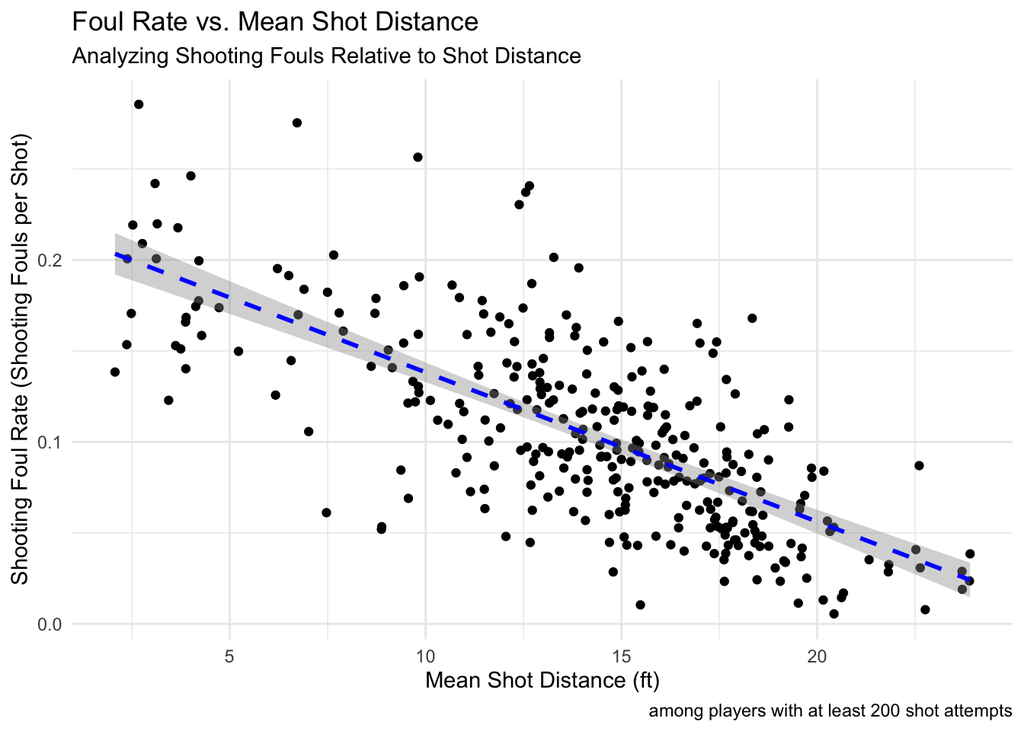

```r
df1 = pbpdata %>%
  select(team, player, shot_distance) %>%
  filter(!is.na(shot_distance)) %>%
  group_by(team, player) %>%
  summarise(
    mean = mean(shot_distance),
    sd = sd(shot_distance),
    count_shots = n()
  )

df2 = pbpdata %>% select(team, player, ftm, fta) %>%
  filter(!is.na(fta)) %>% group_by(team, player) %>%
  summarise(
    ttlftm = sum(ftm),
    ttlfta = sum(fta)
  ) %>% mutate(`ft%` = ttlftm / ttlfta)

df3 = pbpdata %>%
  filter(foul_type == 'Shooting foul') %>%
  select(team, player) %>% group_by(team, player) %>%
  summarise( count_fouls = n())

df <- df3 %>%
  left_join(df1, by = c("team", "player")) %>%
  filter(count_shots >= 200) %>%
  mutate(
    foul_rate = count_fouls / count_shots
  ) %>%
  left_join(df2, by = c('team', 'player'))

ggplot(data = df, aes(x = mean, y = foul_rate)) +
  geom_point() +
  geom_smooth(method = "lm", se = TRUE, color = "blue", linetype = "dashed") +
    labs(
    title = "Foul Rate vs. Mean Shot Distance",
    subtitle = "Analyzing Shooting Fouls Relative to Shot Distance",
    x = "Mean Shot Distance (ft)",
    y = "Shooting Foul Rate (Shooting Fouls per Shot)",
    caption = 'among players with at least 200 shot attempts'
  ) +
  theme_minimal()
```

The analysis reveals (as excepted) a negative linear relationship between the mean shooting distance from the rim and the number of shooting fouls drawn. However, this relationship does not tell the entire story. Below are the fifteen players with the highest shooting fouls per shot attempted rates.

```r
top20 = df %>%
  select(team, player, `ft%`, mean, foul_rate) %>%
  rename(mean_shot_distance = mean,
         shooting_foul_rate = foul_rate) %>%
  arrange(desc(shooting_foul_rate)) %>%
  head(15)
top20 %>% kbl() %>% kable_styling()
```

| team | player | ft% | mean_shot_distance | shooting_foul_rate |
| --- | --- | --- | --- | --- |
| MIN | R. Gobert | 0.6439232 | 2.678273 | 0.2855153 |
| MIL | G. Antetokounmpo | 0.6572890 | 6.720234 | 0.2753835 |
| MIA | J. Butler | 0.8586724 | 9.803946 | 0.2564735 |
| NOP | Z. Williamson | 0.7017893 | 4.007136 | 0.2462087 |
| CHO | N. Richards | 0.7374302 | 3.093085 | 0.2420213 |
| PHI | J. Embiid | 0.8796296 | 12.652348 | 0.2407592 |
| PHO | J. Okogie | 0.7314815 | 12.558139 | 0.2372093 |
| TOR | C. Boucher | 0.7717391 | 12.391705 | 0.2304147 |
| IND | I. Jackson | 0.7142857 | 3.148936 | 0.2198582 |
| GSW | T. Jackson-Davis | 0.5606061 | 2.525526 | 0.2192192 |
| BRK | D. Sharpe | 0.6097561 | 3.676871 | 0.2176871 |
| CHI | A. Drummond | 0.5917431 | 2.770492 | 0.2090164 |
| ORL | M. Wagner | 0.7963801 | 7.654174 | 0.2027257 |
| CHI | D. DeRozan | 0.8525122 | 13.274101 | 0.2014388 |
| WAS | D. Gafford | 0.7058824 | 3.125850 | 0.2006803 |

### Discussion

Among these top fifteen, names such as Giannis Antetokounmpo, Rudy Gobert, and Zion Williamson stand out. These players are renowned for scoring around the rim. However, these athletes have relatively low free throw percentages, ranging between 65-70%. Due to how proficient they are in scoring near the basket, opposing teams often prefer to foul these players, forcing them to the free throw line instead of allowing them to capitalize on their high-percentage shots around the basket. These players are fouled at a rate of approximately 25%, meaning they draw a shooting foul in about one in every four shot attempts.

In contast, players with high free throw percentages, such as Jimmy Butler, DeMar DeRozan, and Joel Embiid, maintain free throw percentages between 85-90%. Although their average shot distance from the rim is greater, they still appear in the top fifteen for shooting foul rates. These players in particular, are tricky mid-range (within 19ft of the rim) players that challenge defenses with a sharp move set, that can trick defensive players into fouling. If we expanded the list, players such as Shai Gilgeous Alexander, James Harden, and LeBron James, have rates around 16% and are known for their ‘downhill’ play styles that are aggressive in driving to the basket, challenging defenses and forcing shooting fouls. In this case, teams are making strategic errors by allowing these players frequent opportunities to reach the free throw line, conceding more (long-run) points through free throws, than defending without fouling.